# Viet History

Duc Du

03 September, 2022

```r
#load("data/hoviet.RData")
```

## Dữ liệu dân số Vietnam từ Gapminder

```r
vietnam <- gapminder %>%
  filter(
    continent == "Asia",
    country == "Vietnam"
  )
head(vietnam)
```

| country | continent | year | lifeExp | pop | gdpPercap |
| --- | --- | --- | --- | --- | --- |
| Vietnam | Asia | 1952 | 40.4 | 26246839 | 605 |
| Vietnam | Asia | 1957 | 42.9 | 28998543 | 676 |
| Vietnam | Asia | 1962 | 45.4 | 33796140 | 772 |
| Vietnam | Asia | 1967 | 47.8 | 39463910 | 637 |
| Vietnam | Asia | 1972 | 50.3 | 44655014 | 700 |
| Vietnam | Asia | 1977 | 55.8 | 50533506 | 714 |

## Đồ thị dân số Việt Nam qua các năm có dữ liệu

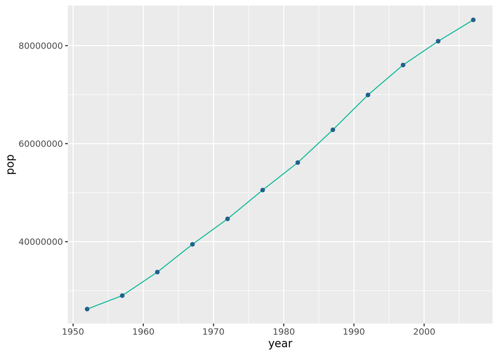

```r
vietnam %>% ggplot(.,aes(x =year, y= pop)) +
  geom_line(color ='#1ABC9C') + geom_point(color='#21618C')
```

## Phân trăm tăng (giảm) dân số qua các năm?

```r
vietnam <- vietnam %>%
  mutate(PercentGrowth = (pop - lag(pop))*100/lag(pop),
         interval = (year - lag(year))) %>%
  arrange(year)
head(vietnam)
```

| country | continent | year | lifeExp | pop | gdpPercap | PercentGrowth | interval |
| --- | --- | --- | --- | --- | --- | --- | --- |
| Vietnam | Asia | 1952 | 40.4 | 26246839 | 605 |  |  |
| Vietnam | Asia | 1957 | 42.9 | 28998543 | 676 | 10.5 | 5 |
| Vietnam | Asia | 1962 | 45.4 | 33796140 | 772 | 16.5 | 5 |
| Vietnam | Asia | 1967 | 47.8 | 39463910 | 637 | 16.8 | 5 |
| Vietnam | Asia | 1972 | 50.3 | 44655014 | 700 | 13.2 | 5 |
| Vietnam | Asia | 1977 | 55.8 | 50533506 | 714 | 13.2 | 5 |

## Sự tăng (giảm) dân số Việt Nam trong quá khứ

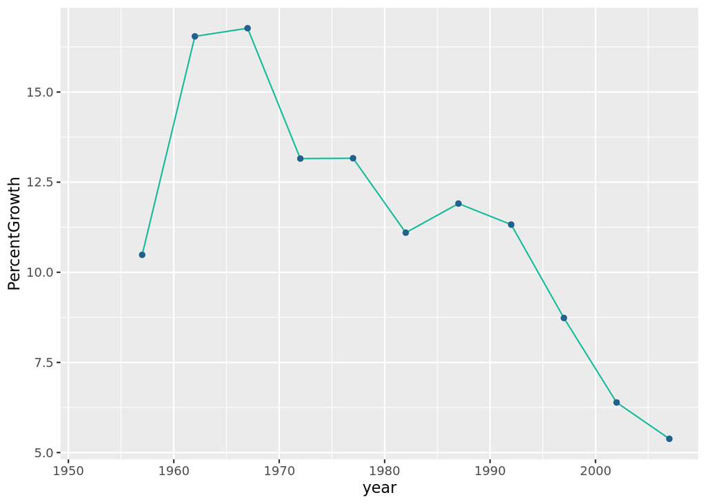

```r
vietnam %>% mutate(PercentGrowth = (pop - lag(pop))*100/lag(pop)) %>%
           ggplot(.,aes(x=year, y=PercentGrowth)) + geom_line(color ='#1ABC9C') + geom_point(color='#21618C')
```

## Mô hình tăng dân số theo cấp số nhân

Giả định quan sát một dân số giả định trong 2 năm. Giả sử có 100 người trong năm đầu và 150 người trong năm thứ 2. Khi đó, tốc độ tăng dân số (population growth rate) trong 2 năm đó bằng $\frac{N2}{N1}=1.5$.

Tổng quát, tốc độ tăng trưởng hàng năm, $\lambda$ bằng số lượng người trong 1 năm so với năm trước đó:

$$\lambda = \frac{N_{t+1}}{N_t}$$

Nếu tốc độ tăng trưởng này không đổi trong $t$ năm và quy mô dân số ban đầu là $N_{0}$, thì quy mô dân số tại năm $t$ bằng:

$$N_{t}=N_{0}\lambda^t$$

Đây là mô hình *geometric population growth*, tức là dân số tăng hình học theo các bước thời gian rời rạc và tốc độ tăng trưởng không đổi.

*Exponential population growth* (tăng trưởng dân số theo cấp số nhân) xảy ra khi dân số gia tăng trong thời gian liên tục với tốc độ tăng trưởng không đổi, $r$:

$$N_{t} = N_{0}e^{rt}$$

Ở đây, $r$ là tốc độ tăng trưởng tức thời (*instantaneous rate of growth*) bằng tỉ lệ sinh (số sinh trên mỗi cá nhân) trừ đi tỉ lệ chết (số chết trên mỗi cá nhân) tại bất kỳ khoảng thời gian nào.

Mô hình tăng trưởng theo cấp số nhân và hình học rất giống nhau, trừ một số tính chất toán học. Với 1 đơn vị thời gian nhất định, chúng ta có thể chuyển đổi qua 2 mô hình dễ dàng. Lưu ý $\lambda = e^r$ và $\ln\lambda = r$

```r
N0 = 100
lambda = 1.0048
t = 0:1120
N = N0 * lambda^t
round(N, 0)
```

```
##    [1]   100   100   101   101   102   102   103   103   104   104   105   105
##   [13]   106   106   107   107   108   108   109   110   110   111   111   112
##   [25]   112   113   113   114   114   115   115   116   117   117   118   118
##   [37]   119   119   120   121   121   122   122   123   123   124   125   125
##   [49]   126   126   127   128   128   129   130   130   131   131   132   133
##   [61]   133   134   135   135   136   137   137   138   138   139   140   140
##   [73]   141   142   143   143   144   145   145   146   147   147   148   149
##   [85]   150   150   151   152   152   153   154   155   155   156   157   158
##   [97]   158   159   160   161   161   162   163   164   165   165   166   167
##  [109]   168   169   169   170   171   172   173   173   174   175   176   177
##  [121]   178   178   179   180   181   182   183   184   185   185   186   187
##  [133]   188   189   190   191   192   193   194   195   196   196   197   198
##  [145]   199   200   201   202   203   204   205   206   207   208   209   210
##  [157]   211   212   213   214   215   216   217   218   219   220   221   222
##  [169]   224   225   226   227   228   229   230   231   232   233   235   236
```

[output cut: 79 more lines]

```r
# I'm rounding this here because it doesn't make sense to have a fraction of an individual.
```

Biểu đồ phân bố dân số họ Khúc từ năm 900 đến 2020

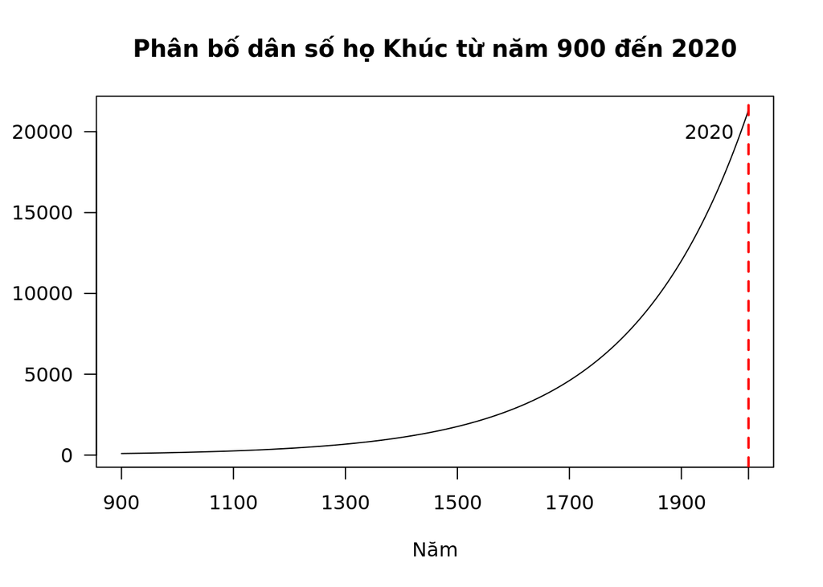

```r
plot(t, N, type = "l", pch = 19, las = 1, xaxt='n', xlab="Năm", ylab="", main="Phân bố dân số họ Khúc từ năm 900 đến 2020")
axis(side=1, at=c(0, 200, 400, 600, 800, 1000, 1120), labels=c("900", "1100", "1300", "1500", "1700", "1900", "2020"))
abline(v=1120, col="red", lty=2, lwd=2)
text(1050, 20000, "2020")
```

## Thay đổi tốc độ tăng trưởng dân số

Bây giờ, lập mô hình dân số với các tỉ lệ tăng trưởng khác nhau, $\lambda$. Với 2 tham số thay đổi ($t$ và $\lambda$). Điều đó nghĩa là chúng ta cần đầu ra là một ma trận, với 1 tham số ($t$) theo hàng và một tham số khác ($\lambda$) theo cột.

Sau đó, chúng ta cần xác định một số $\lambda$ (ở đây, là 1.0044, 1.0046, 1.0048, 1.0050 và 1.052) sau đó chạy tất cả các khả năng theo công thức tỉ lệ tăng trưởng dân số. Hàm này sẽ trả về một vector hoặc một ma trận, tùy thuộc vào dạng đơn giản nhất.

```r
N0 = 100
lambda = seq(1.0044, 1.0052, by=0.0002)
t = 0:1120
N = sapply(lambda, function(lambda) N0 * lambda^t)
```

Kết quả thu được là 1 ma trận với 1121 hàng tương ứng với $t$ = 0 đến 1120 và 5 cột tương ứng với 5 giá trị của $\lambda$ (1.0044, 1.0046, 1.0048, 1.0050, 1.052). Biểu đồ phân bố dân số được biểu diễn như sau:

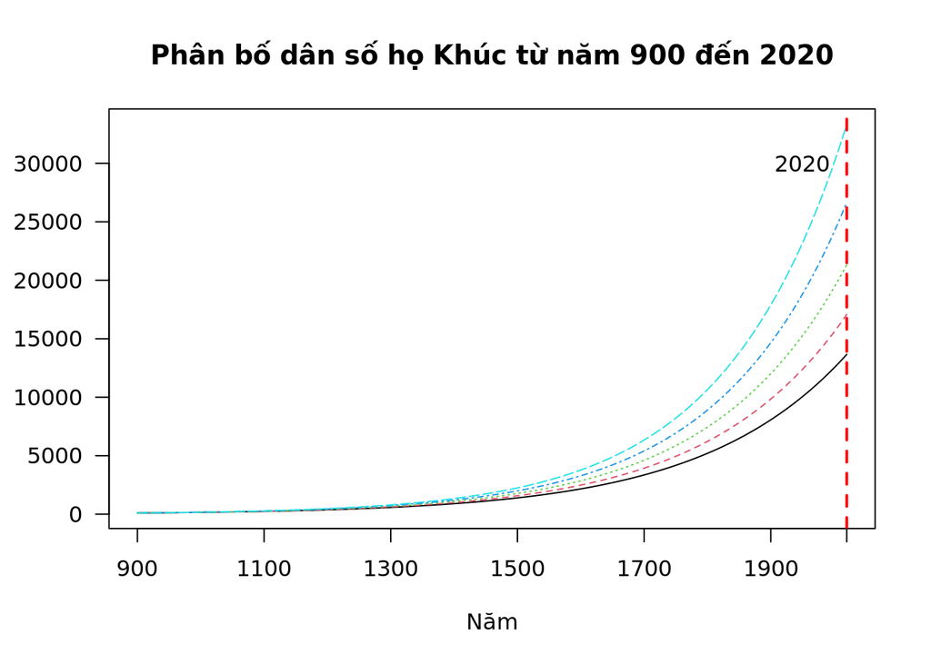

```r
matplot(t, N, las = 1, xaxt='n', type = "l", pch = 19, xaxt='n', xlab="Năm", ylab="", main="Phân bố dân số họ Khúc từ năm 900 đến 2020")
#plot(t, N, type = "l", pch = 19, las = 1, xaxt='n')
axis(side=1, at=c(0, 200, 400, 600, 800, 1000, 1120), labels=c("900", "1100", "1300", "1500", "1700", "1900", "2020"))
abline(v=1120, col="red", lty=2, lwd=2)
text(1050, 30000, "2020")
```

Phân bố dân số họ Khúc từ năm 900 đến 2020

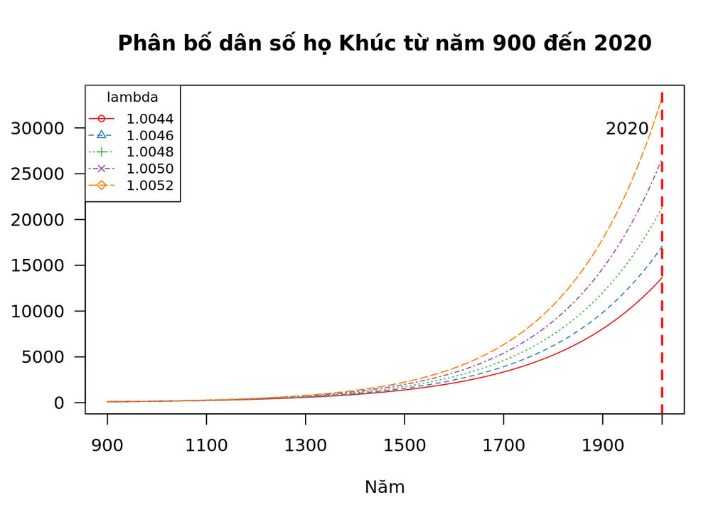

```r
library(RColorBrewer)
colors = brewer.pal(5, "Set1")
matplot(t, N, type = "l", las = 1, pch = 1:5, col = colors, lty = 1:5, xaxt='n', xlab="Năm", ylab="", main="Phân bố dân số họ Khúc từ năm 900 đến 2020")
axis(side=1, at=c(0, 200, 400, 600, 800, 1000, 1120), labels=c("900", "1100", "1300", "1500", "1700", "1900", "2020"))
abline(v=1120, col="red", lty=2, lwd=2)
text(1050, 30000, "2020")
legend("topleft", legend = c("1.0044", "1.0046", "1.0048", "1.0050", "1.0052"),
    title = "lambda", pch = 1:5, lty = 1:5, col = colors, cex = 0.8)
```

Dân số tăng khi $\lambda$ > 1 và ngược lại.

Với tốc độ tăng trưởng tức thời (instantaneous rate of growth), $r = \ln\lambda$:

- Dân số không thay đổi khi $\lambda$ = 1 hoặc $r$ = 0
- Dân số tăng khi $\lambda$ > 1 hoặc $r$ > 0
- Dân số giảm khi $\lambda$ < 1 hoặc $r$ < 0

## Mô hình ngẫu nhiên

Chúng ta đang giả định rằng tốc độ gia tăng dân số là không đổi theo thời gian. Điều này rõ ràng không phải là đúng trong hầu hết các quần thể tự nhiên. Ngay cả khi bỏ qua các cơ chế phụ thuộc vào mật độ, tỷ lệ tăng trưởng phổ biến cũng dao động do các nguồn ngẫu nhiên khác nhau (tức là ngẫu nhiên). Một nguồn chính của tính ngẫu nhiên trong tỷ lệ gia tăng dân số là *môi trường ngẫu nhiên*: tức là sự biến động ngẫu nhiên của tỷ lệ gia tăng dân số do các năm tốt và xấu.

Giả sử một quần thể có tỷ lệ tăng dân số ổn định – tức là tỷ lệ tăng trưởng tức thời trung bình, $\bar{r}$ = 0. Nhưng tỷ lệ tăng trưởng thực tế dao động xung quanh mức trung bình này với một số phương sai, $\sigma_{r}^2$ = 0.01. Do đó, đối với mỗi bước thời gian (giả sử, 1120), ta có thể lấy ngẫu nhiên một số từ phân phối chuẩn với giá trị trung bình là 0 và phương sai là 0,01 (hoặc độ lệch chuẩn $sd = \sqrt{var} = 0.1$), như sau:

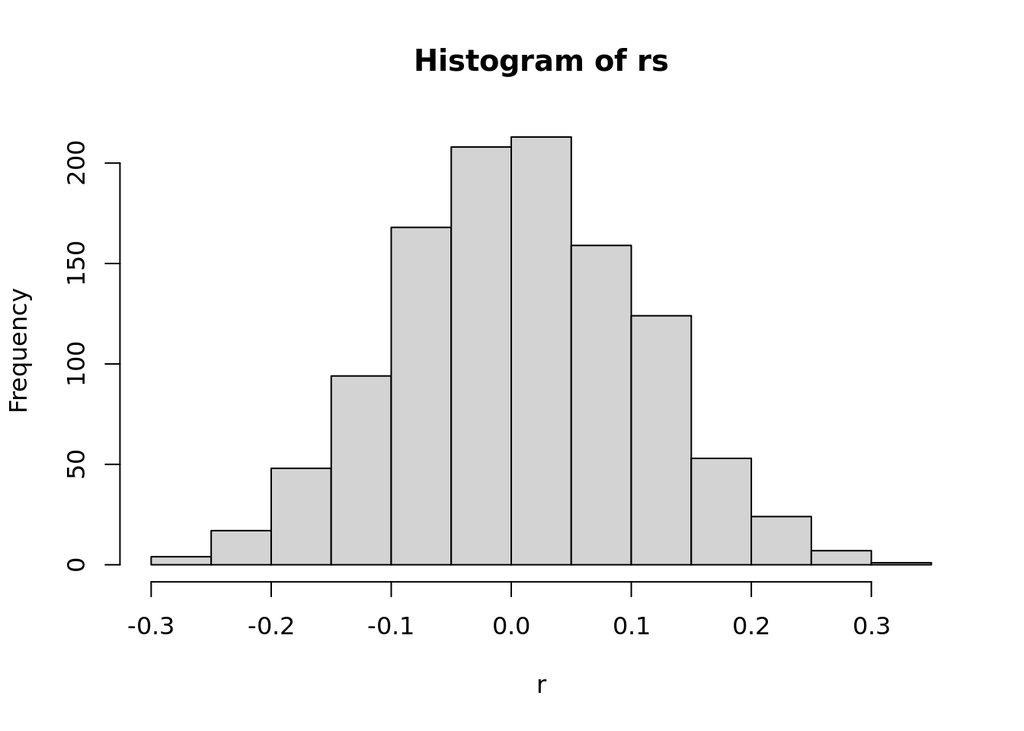

```r
set.seed(2)
rs = rnorm(1120, mean = 0, sd = 0.1)
hist(rs, xlab = "r")
```

Để có tính nhất quán trong mục đích lập mô hình, ta chuyển đổi phân phối tỷ lệ tăng trưởng này thành tỷ lệ tăng trưởng dân số rời rạc $\lambda$, được biểu thị bằng $e^r$. Theo đó, phân phối $\lambda$ trong trường hợp này là:

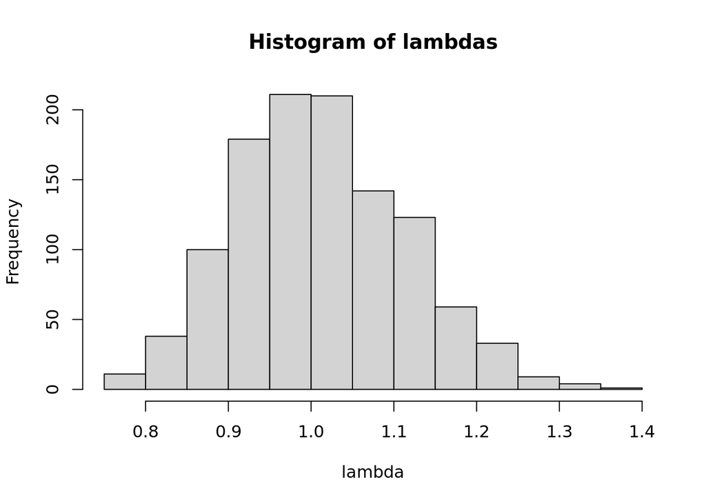

```r
hist(exp(rs), xlab = "lambda", main = "Histogram of lambdas")
```

2 phân phối nhìn khá giống nhau, nhưng phân phối trên (phân phối của $r$) là 1 **phân phối chuẩn** tập trung quanh 0, và phân phối dưới (phân phối của $\lambda$) là **phân phối log-normal** – nghĩa là, log của giá trị là 1 phân phối chuẩn – tập trung quanh 1.

Chúng ta có thể lấy trực tiếp phân phối của $\lambda$ từ phân phối log-normal:

```r
set.seed(2)
lambdas = rlnorm(1120, meanlog = 0, sdlog = 0.1)
round(lambdas, 2)
```

```
##    [1] 0.91 1.02 1.17 0.89 0.99 1.01 1.07 0.98 1.22 0.99 1.04 1.10 0.96 0.90
##   [15] 1.20 0.79 1.09 1.00 1.11 1.04 1.23 0.89 1.17 1.22 1.00 0.78 1.05 0.94
##   [29] 1.08 1.03 1.08 1.03 1.11 0.97 0.93 0.94 0.84 0.91 0.95 0.98 0.96 0.82
##   [43] 0.92 1.21 1.06 1.22 0.97 0.99 0.98 0.89 0.92 1.23 0.95 1.14 0.90 0.82
##   [57] 0.97 1.10 1.12 1.18 0.84 1.23 0.93 1.02 1.05 0.92 0.82 0.95 1.01 0.91
##   [71] 0.91 1.03 0.99 1.04 0.99 0.91 1.14 1.08 1.11 0.87 1.10 0.84 0.95 0.87
##   [85] 0.80 1.20 0.94 0.97 0.96 1.04 1.17 1.18 0.89 0.87 0.86 0.88 1.22 1.00
##   [99] 0.92 0.94 1.11 1.03 0.97 0.93 0.92 1.23 1.10 1.22 0.96 0.97 0.90 0.98
##  [113] 1.05 1.15 1.06 1.05 1.13 1.12 1.01 0.92 1.13 1.01 1.19 0.96 0.90 1.06
##  [127] 0.94 1.07 0.84 0.84 1.07 1.03 1.09 0.82 1.13 1.13 1.11 1.08 1.23 0.86
##  [141] 0.94 1.04 0.92 1.01 1.08 0.94 1.07 1.06 0.92 0.91 1.10 0.98 1.07 0.92
##  [155] 1.14 0.87 1.08 1.05 1.03 1.07 1.04 0.94 0.97 1.04 0.88 0.92 1.23 0.81
##  [169] 0.88 1.10 1.12 1.09 1.01 1.03 0.91 0.94 0.97 0.91 1.09 0.85 0.90 0.88
##  [183] 1.04 0.89 1.06 1.12 1.00 1.05 0.94 1.05 0.88 0.99 0.87 0.97 1.11 1.07
##  [197] 0.96 0.92 0.92 0.93 1.03 0.90 1.33 1.02 0.91 1.04 0.99 0.97 1.06 1.02
```

[output cut: 65 more lines]

Sử dụng vòng lặp để tính $N_{t}$ cho mỗi bước thời gian $t$ và lưu trữ nó dưới dạng vector.

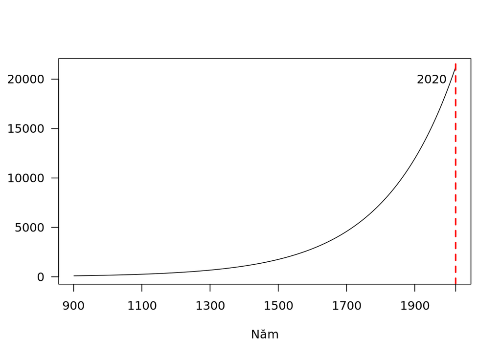

```r
N0 = 100  #initial population size
times = 1120  #number of years into the future
N = vector(length = times)  #empty vector to store pop. sizes
N[1] = N0  #initial population size should be the first N
lambda = 1.0048  #growth rate
# start loop: Take previous year's N and multiply by lambda
for (t in 2:times) {
    N[t] = N[t - 1] * lambda
}

plot(1:times, N, type = "l", pch = 19, las = 1, xaxt='n', xlab="Năm", ylab="")
axis(side=1, at=c(0, 200, 400, 600, 800, 1000, 1120), labels=c("900", "1100", "1300", "1500", "1700", "1900", "2020"))
abline(v=1120, col="red", lty=2, lwd=2)
text(1050, 20000, "2020")
```

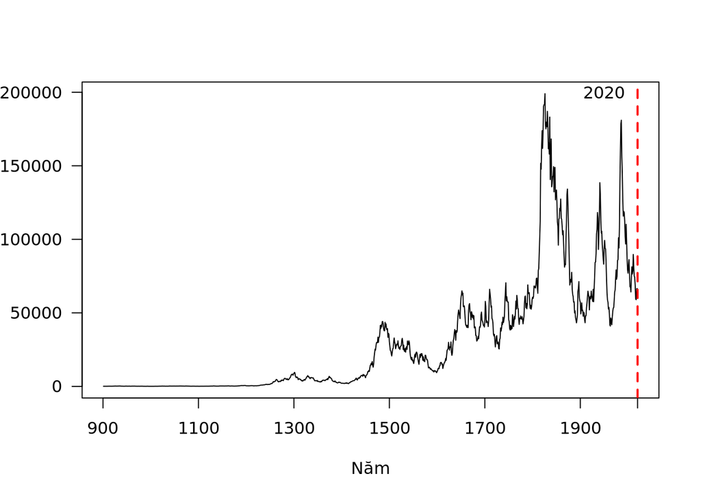

```r
set.seed(2)
N0 = 100  #initial population size
times = 1120  #number of years into the future
N = vector(length = times)  #empty vector to store pop. sizes
N[1] = N0  #initial population size should be the first N

# lambdas--we only need 19 numbers because growth only
# happens between 2 years.
lambda = rlnorm(times - 1, meanlog = 0, sdlog = 0.1)

# start loop: Take previous year's N and multiply by lambda
for (t in 2:times) {
    N[t] = N[t - 1] * lambda[t - 1]
}

plot(1:times, N, type = "l", pch = 19, las = 1, xaxt='n', xlab="Năm", ylab="")
axis(side=1, at=c(0, 200, 400, 600, 800, 1000, 1120), labels=c("900", "1100", "1300", "1500", "1700", "1900", "2020"))
abline(v=1120, col="red", lty=2, lwd=2)
text(1050, 200000, "2020")
```

Chạy mô hình mô phỏng nhiều lần (10 lần) và vẽ biểu đồ kết quả trong 1 mô hình.

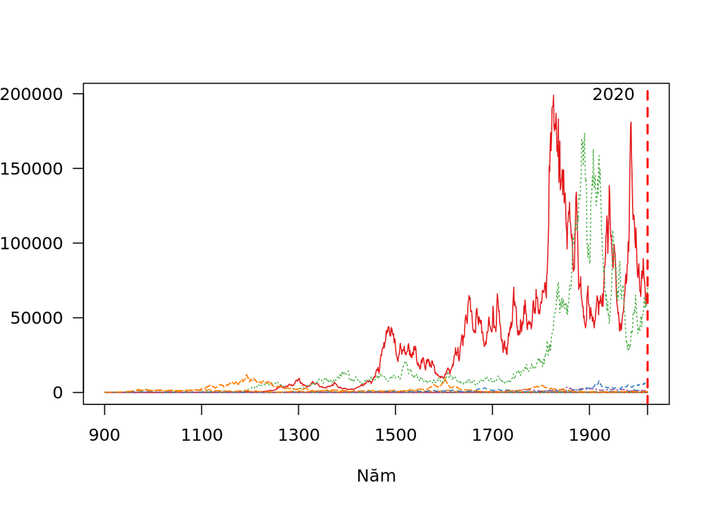

```r
# multiple simulations
set.seed(2)
sims = 10
outmat = sapply(1:sims, function(x) {
    times = 1120
    N0 = 100
    N = vector(length = times)
    N[1] = N0
    lambda = rlnorm(times - 1, meanlog = 0, sdlog = 0.1)
    for (t in 2:times) {
        N[t] = N[t - 1] * lambda[t - 1]
    }
    N
})

matplot(1:times, outmat, type = "l", las = 1, pch = 1:5, col = colors, lty = 1:5, xaxt='n', xlab="Năm", ylab="")
axis(side=1, at=c(0, 200, 400, 600, 800, 1000, 1120), labels=c("900", "1100", "1300", "1500", "1700", "1900", "2020"))
abline(v=1120, col="red", lty=2, lwd=2)
text(1050, 200000, "2020")
```

Áp dụng hệ số vào mô hình phân bố các dòng họ

```r
N0 = 65000
lambda = 1.0048
t = 0:1020
N = N0 * lambda^t
round(N, 0)
```

```
##    [1]   65000   65312   65625   65940   66257   66575   66895   67216   67538
##   [10]   67863   68188   68516   68844   69175   69507   69841   70176   70513
##   [19]   70851   71191   71533   71876   72221   72568   72916   73266   73618
##   [28]   73971   74326   74683   75042   75402   75764   76127   76493   76860
##   [37]   77229   77600   77972   78346   78722   79100   79480   79861   80245
##   [46]   80630   81017   81406   81797   82189   82584   82980   83378   83779
##   [55]   84181   84585   84991   85399   85809   86221   86635   87050   87468
##   [64]   87888   88310   88734   89160   89588   90018   90450   90884   91320
##   [73]   91759   92199   92642   93086   93533   93982   94433   94886   95342
##   [82]   95799   96259   96721   97186   97652   98121   98592   99065   99541
##   [91]  100018  100498  100981  101466  101953  102442  102934  103428  103924
##  [100]  104423  104924  105428  105934  106442  106953  107467  107983  108501
##  [109]  109022  109545  110071  110599  111130  111663  112199  112738  113279
##  [118]  113823  114369  114918  115470  116024  116581  117141  117703  118268
##  [127]  118836  119406  119979  120555  121134  121715  122299  122886  123476
```

[output cut: 99 more lines]

Phân bố dân số họ Trần từ năm 1000 đến 2020

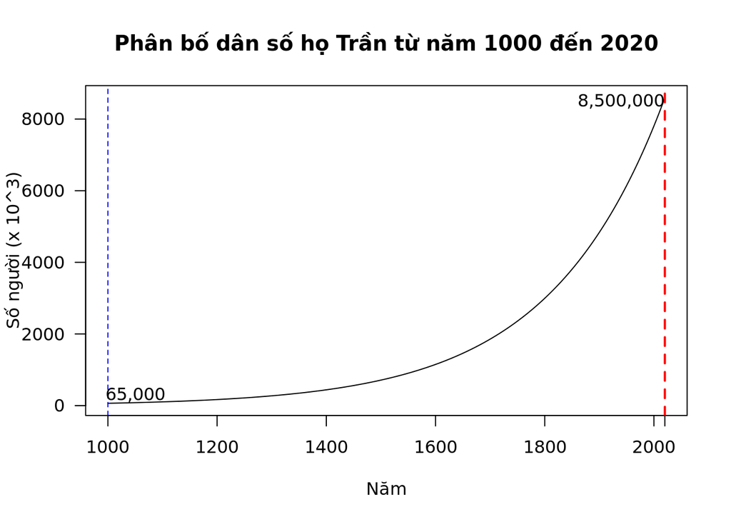

```r
plot(t, N/1000, type = "l", pch = 19, las = 1, xaxt='n', xlab="Năm", ylab="Số người (x 10^3)", main="Phân bố dân số họ Trần từ năm 1000 đến 2020")
axis(side=1, at=c(0, 200, 400, 600, 800, 1000, 1020), labels=c("1000", "1200", "1400", "1600", "1800", "2000", "2020"))
abline(v=c(0,1020), col=c("blue", "red"), lty=c(2,2), lwd=c(1, 2))
text(940, 8500, "8,500,000")
text(50, 300, "65,000")
```

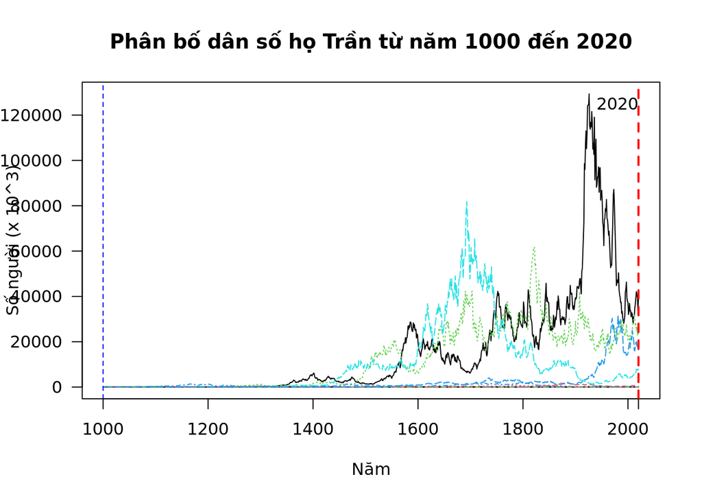

```r
# multiple simulations
set.seed(2)
sims = 10
times=1020
outmat = sapply(1:sims, function(x) {
    times = 1020
    N0 = 65000
    N = vector(length = times)
    N[1] = N0
    lambda = rlnorm(times - 1, meanlog = 0, sdlog = 0.1)
    for (t in 2:times) {
        N[t] = N[t - 1] * lambda[t - 1]
    }
    N
})

matplot(1:times, outmat/1000, type = "l", las = 1, xaxt='n', xlab="Năm", ylab="Số người (x 10^3)", main="Phân bố dân số họ Trần từ năm 1000 đến 2020")
axis(side=1, at=c(0, 200, 400, 600, 800, 1000, 1020), labels=c("1000", "1200", "1400", "1600", "1800", "2000", "2020"))
abline(v=c(0,1020), col=c("blue", "red"), lty=c(2,2), lwd=c(1, 2))
text(980, 125000, "2020")
```